# Álgebra Matricial

Lições na linguagem R

Author

Affiliation

Isabel Azar de Holanda

Faculdade SENAC DF

Published

21/08/2025

## Matriz

Matrizes são tabelas retangulares de números, expressões matemáticas ou símbolos, cujo elementos são arranjados em n linhas e p colunas. A matriz M abaixo, por exemplo, organiza cada elemento **a<sub>ij</sub>** em 2 linhas e 3 colunas.

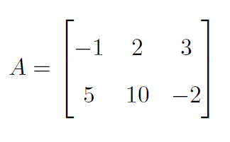

Matriz 2x3

No R, a matriz é uma estrutura de dados homogênea (deve conter mesmo tipo de dados, e.i. numérico, caracteres, lógico) de duas dimensões. Sua sintaxe básica é realizada por meio da função *matrix*( ), tendo como argumentos os elementos que compõem a matriz, na forma de um vetor, e o número de linhas e colunas.

Vamos criar agora uma matriz quadrada M1 de dimensão 3, com valores inteiros positivos de 1 a 9:

**Ocultar/mostrar**

```r
# Matriz quadrada 3x3 com valores de 1 a 9 (preenchida por coluna por padrão)
M1 <- matrix(c(1:9) , nrow = 3, ncol = 3)
M1
```

```
     [,1] [,2] [,3]
[1,]    1    4    7
[2,]    2    5    8
[3,]    3    6    9
```

Por *default* os elementos são organizados por coluna na matriz. Caso se deseje que estes sejam organizados por linha, usa-se o argumento *byrow* = TRUE.

Vamos criar uma nova matriz com os mesmos valores da M1, agora organizados por linha.

**Ocultar/mostrar**

```r
# Mesmos valores, agora preenchendo por linha
M2 <- matrix(c(1:9), nrow = 3, byrow = TRUE)
M2
```

```
     [,1] [,2] [,3]
[1,]    1    2    3
[2,]    4    5    6
[3,]    7    8    9
```

A função *matrix*( ), na realidade, organiza as dimensões de um vetor qualquer. Na prática, não é necessário informar o número de linhas e de colunas se o vetor de dados é informado. Contudo, tal prática facilita a leitura do código.

Vamos criar uma matriz M3 retangular de dimensão 2x3 com valores aleatórios:

**Ocultar/mostrar**

```r
V1 <- c(2, 3, 0.5, -1, 4.3, 100)

M3 <- matrix(data = V1, nrow =  2)
M3
```

```
     [,1] [,2]  [,3]
[1,]    2  0.5   4.3
[2,]    3 -1.0 100.0
```

Para criar uma matriz M4 quadrada de dimensão 6 contendo um único valor, e.g. matriz nula, informa-se este valor no argumento **data** em conjunto com o número de linhas e colunas.

**Ocultar/mostrar**

```r
# Matriz 6x6 contendo apenas zeros (matriz nula)
M4 <- matrix(0, nrow = 6, ncol = 6)
M4
```

```
     [,1] [,2] [,3] [,4] [,5] [,6]
[1,]    0    0    0    0    0    0
[2,]    0    0    0    0    0    0
[3,]    0    0    0    0    0    0
[4,]    0    0    0    0    0    0
[5,]    0    0    0    0    0    0
[6,]    0    0    0    0    0    0
```

Caso seja de interesse alocar uma matriz vazia, basta informar os argumentos ncol e nrow. Esta será completada com o valor lógico **NA** (do inglês, *not avaliable*).

Vamos criar agora uma matriz vazia M5 retangular de dimensão 2x3:

**Ocultar/mostrar**

```r
# Matriz "vazia" 2x3 preenchida com NA
M5 <- matrix(NA, nrow = 2, ncol = 3)
M5
```

```
     [,1] [,2] [,3]
[1,]   NA   NA   NA
[2,]   NA   NA   NA
```

## Operações Matriciais

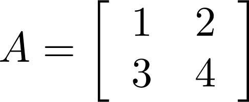

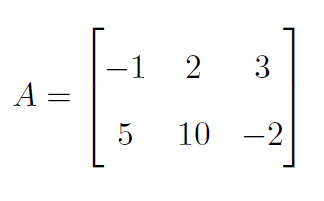

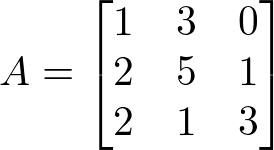

Matriz 3x3

Vamos criar agora as matrizes M6, M7, M8 e M9:

**Ocultar/mostrar**

```r
# Matrizes para operações
# 2x2 (invertível)
M6 <- matrix(c(2, 3, 5, -6), nrow = 2, byrow = TRUE)

# 2x2
M7 <- matrix(c(1, 2,-2, 4), nrow = 2, byrow = TRUE)

# 2x3
M8 <- matrix(c(1, -2, 3,0, 4,  2), nrow = 2, byrow = TRUE)

# 3x3
M9 <- matrix(c(0.8, 0.6, 0, -0.6, 0.8, 0, 0, 0, 1), nrow = 3, byrow = TRUE)

list(M6 = M6, M7 = M7, M8 = M8, M9 = M9)
```

```
$M6
     [,1] [,2]
[1,]    2    3
[2,]    5   -6

$M7
     [,1] [,2]
[1,]    1    2
[2,]   -2    4

$M8
     [,1] [,2] [,3]
[1,]    1   -2    3
[2,]    0    4    2

$M9
     [,1] [,2] [,3]
[1,]  0.8  0.6    0
[2,] -0.6  0.8    0
[3,]  0.0  0.0    1
```

## Soma e subtração

Dada duas matrizes de mesma dimensionalidade, a matriz resultante da soma / substração destas matrizes corresponde à matriz cujos elementos são a soma / subtração dos elementos das matrizes originais.

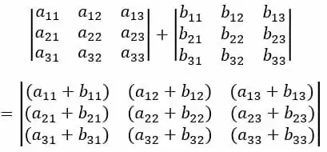

Adição de matrizes

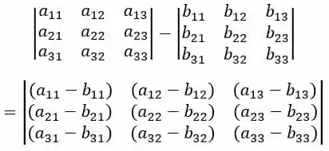

Subtração de matrizes

No R, para a soma e substração de matrizes usa-se a mesma sintaxe que na operação entre escalares.

Vamos somar as matrizes M6 e M7 resultando na matriz M10:

**Ocultar/mostrar**

```r
# Soma: M10 = M6 + M7
M10 <- M6 + M7
M10
```

```
     [,1] [,2]
[1,]    3    5
[2,]    3   -2
```

**Ocultar/mostrar**

```r
# Subtração: M7 - M6
M11 <- M7 - M6
M11
```

```
     [,1] [,2]
[1,]   -1   -1
[2,]   -7   10
```